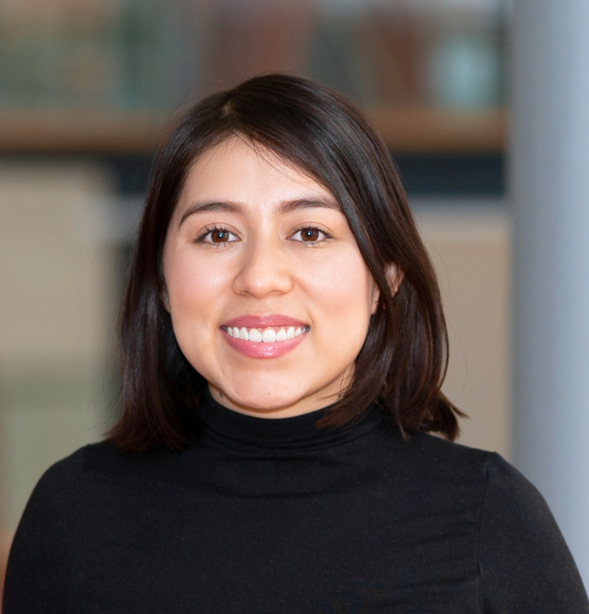

# Judith Ballesteros Villascán

## About myself

I am a mexican scientist starting my PhD at the [**Max Planck Institute for Evolutionary Anthropology**](https://www.eva.mpg.de/index/), which combines my passions: Evolution and Bioinformatics.

As part of the [**Tropical Archaeogenomics Group**](https://www.eva.mpg.de/tropical-archaeogenomics/overview/), my research focuses on population genomics across time in the Americas and other tropical regions.

Besides my academic interests, I like training at the GYM, making videos of the new places I visit, and finding good places to eat.

## Education

**MSc in Integrative Biology** | National Laboratory of Genomics for Biodiversity (LANGEBIO) | September 2020 - September 2022

**B.S. in Biotechnology** graduated with honors | Meritorious Autonomous University of Puebla | August 2015 - January 2020

## Oral Presentations and Posters

**EMBO | EMBL Symposium - Reconstructing the human past: using ancient and modern genomics**. | Heidelberg, Germany - September 2024 | Short talk

**Society for Molecular Biology and Evolution Meeting (SMBE2024)**. | Puerto Vallarta, Mexico - July 2024 | Poster

**Primer Congreso Internacional EnviroEpiHealth[MX]**. | Puebla, Mexico - June 2024 | Oral speaker

**10th Meeting of the International Society for Biomolecular Archaeology (ISBA10)**. | Estonian National Museum, Tartu, Estonia - September 2023 | Poster

**SMBE2021**. | Held virtually due to COVID - July 2021 | Poster

**INMEGEN. Students meeting**. | Mexico City - December 2018 | Poster

## Teaching Experience

[**Bytesize: Using nf-core configs in custom pipelines**](https://nf-co.re/events/2023/bytesize_custom_configs). | Instructor | October 2023

**R-Ladies chapters 4-8 of Software Carpentry “R for Reproducible Scientific Analysis”**. | R instructor | UNAM Center for Mathematical Sciences | 2022

**Habilidades Básicas en Linux Vol 1**. | Instructor | INMEGEN | June 2022

## Research Experience

**Max Planck Institute for Evolutionary Anthropology** | [Tropical Archaeogenomics / Kathrin Nägele Lab](https://www.eva.mpg.de/tropical-archaeogenomics/overview/) | PhD Candidate | February 2023 - Present

**LANGEBIO-CINVESTAV** | [RegRNA Lab / Selene Fernandes-Valverde Lab](http://regrnalab.github.io/) | Master’s student | January 2021 - September 2022

**LANGEBIO-CINVESTAV** | [Human Population Genomics Lab /Andres Moreno-Estrada Lab](http://www.morenolab.org/) | Collaborator for Master’s project | January 2021 - September 2022

**LANGEBIO-CINVESTAV** | [Human Population Genomics Lab / Andres Moreno-Estrada Lab](http://www.morenolab.org/) | Rotation project | November 2020 - January 2021

**LANGEBIO-CINVESTAV** | [Evolutionary genetic interactions and paleogenomics Lab / Rafael Montiel Lab](https://langebio.cinvestav.mx/en/Dr-Rafael-Montiel) | Rotation project | October 2020 - November 2020

**INMEGEN-IBT** | [Enrique Morett-Sánchez Lab](https://www.ibt.unam.mx/) | Research Assistant of the National System of Researchers level III supervised by Israel Aguilar-Ordoñez (Professional practices) | October 2018 - January 2020

**INMEGEN** | [Cristóbal Fresno Rodríguez](https://www.inmegen.gob.mx/) | Undergraduate researcher supervised by Israel Aguilar-Ordoñez | October 2018 - January 2020

**Centro de Investigaciones en Ciencias Microbiológicas** | [Laboratorio de Genética Molecular Microbiana / Miguel Casteñeda-Lucio Lab](https://icuap.buap.mx/content/centro-de-investigaciones-en-ciencias-microbiol%C3%B3gicas) | Highschool student and undergraduate researcher supervised by Liliana López-Pliego (Doing Science in BUAP and Social Service) | April 2015 - October 2018

## Courses and Meetings

**Summer course in analysis of high throughput data for population genetics** | August 2023 | University of Copenhagen

**AGAR Workshop on Computational Genetics** | July 2022 | Online

**Python for Genomic Data Science** | December 2021 | Online Johns Hopkins University

**Course, Statistics for Genomic Data Science** | August 2021 | Online Johns Hopkins University

**5th MexPopGen**, which brings together the scientific community with an interest in the area of population genetics to share the advances | December 2020 | Online INMEGEN

**4th MexPopGen**. | January 2019 | LANGEBIO, LIIGH, UNAM, ENAH and CONABIO - Mexico City

**Practical workshop on Large-Scale Genomic Data Analyses: GWAS in structured populations.** | November 2018 | LANGEBIO - Irapuato, Guanajuato, Mexico

**Comprehensive Workshop for the analysis of genomic and transcriptomic data given by the Massive Sequencing Unit.** | January 2018 | IBT, UNAM - Cuernavaca, Morelos, Mexico.

**International Bioinformatics Workshops at the Center for Genomic Sciences of the UNAM: Genome Assembly and Annotation.** | July 2017 | IBT, UNAM - Cuernavaca, Morelos, Mexico

**International Bioinformatics Workshops at the Center for Genomic Sciences of the UNAM: Introduction to Human Genetics.** | January 2017 | IBT, UNAM - Cuernavaca, Morelos, Mexico

**Genomeeting by Winter Genomics** | October 2016 | INMEGEN - Mexico City, Mexico

**4th Biochemistry Congress from the Mexican Biochemistry Society (SMB)** | October 2016 | Aguascalientes, Mexico

**Bacterias Biochemistry and Molecular Biology IV Congress from SMB** | October 2015 | Puebla, Mexico